# Belgium’s Births, 1840–2024: A Data Story

Beverley Ogenche

13 November 2026

# Introduction

In 2024, Belgium recorded **109,154** live births. Over the last 185 years, only 5 years had fewer (1916, 1917, 1918, 1941, 1942), all during a world war.

This story asks one question: **how did a country that once had about 202,000 births a year reach a peacetime low?** The answer comes in five chapters: growth, war, boom, bust and a new decline.

The data are official annual live births in Belgium by sex, taken from the Human Mortality Database (HMD 2026).

# The data

```r
tibble(
  Variable = c("PopName", "Area", "Sex", "Year", "YearReg", "RefCode", "Access",
               "Births", "NoteCode1-3", "LDB"),
  Meaning = c(
    "Population code (always BEL)",
    "Territory or sub-series the count covers",
    "f = female, m = male",
    "Year of birth",
    "Year of registration",
    "Code for the original data source",
    "Access level (O = open)",
    "Number of live births",
    "HMD footnote codes",
    "1 = row used in the final HMD series, 0 = not used"
  )
)
```

| Variable | Meaning |
| --- | --- |
| PopName | Population code (always BEL) |
| Area | Territory or sub-series the count covers |
| Sex | f = female, m = male |
| Year | Year of birth |
| YearReg | Year of registration |
| RefCode | Code for the original data source |
| Access | Access level (O = open) |
| Births | Number of live births |
| NoteCode1-3 | HMD footnote codes |
| LDB | 1 = row used in the final HMD series, 0 = not used |

The raw file has 568 rows. Some years appear more than once because HMD keeps several areas and sources side by side. Keeping only the rows with `LDB = 1` leaves **one row per year and sex** for 1840–2024, which is the series used below. The method behind these choices is described in the HMD Methods Protocol (Wilmoth et al. 2021).

# The story at a glance

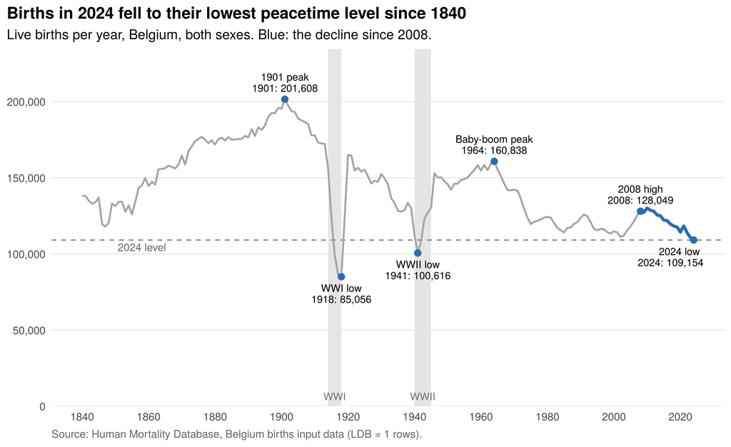

```r
labels <- tot %>%
  filter(Year %in% c(1901, 1918, 1941, 1964, 2008, last_year)) %>%
  mutate(
    name  = c("1901 peak", "WWI low", "WWII low", "Baby-boom peak",
              "2008 high", paste(last_year, "low")),
    label = paste0(name, "\n", Year, ": ", fmt(births)),
    vjust = ifelse(name %in% c("WWI low", "WWII low", paste(last_year, "low")), 1.4, -0.4),
    hjust = ifelse(Year == last_year, 0.85, 0.5)
  )

ggplot(tot, aes(Year, births)) +
  add_war_bands() +
  geom_hline(yintercept = last_births, linetype = "dashed", colour = "grey50") +
  annotate("text", x = 1858, y = last_births, label = paste(last_year, "level"),
           vjust = 1.4, size = 3.3, colour = "grey40") +
  geom_line(colour = grey, linewidth = 0.8) +
  geom_line(data = filter(tot, Year >= 2008), colour = accent, linewidth = 1.3) +
  geom_point(data = labels, colour = accent, size = 2.4) +
  geom_text(data = labels, aes(label = label, vjust = vjust, hjust = hjust),
            size = 3.2, lineheight = 0.9) +
  scale_y_continuous(labels = label_comma(), limits = c(0, 230000),
                     expand = expansion(mult = c(0, 0.02))) +
  scale_x_continuous(breaks = seq(1840, 2020, 20)) +
  labs(
    title = paste("Births in", last_year, "fell to their lowest peacetime level since 1840"),
    subtitle = "Live births per year, Belgium, both sexes. Blue: the decline since 2008.",
    x = NULL, y = NULL, caption = hmd_caption
  )
```

# Insight 1: A century of growth, peaking in 1901

Births rose 46% between 1840 and 1901, from 138,142 to an all-time high of **201,608**. Births grew because the population did: more women of childbearing age meant more babies, even if each family’s size stayed the same.

The one clear break is **1846–47**, when births fell about 14% in two years. This coincides with the potato blight and famine that hit Flanders hard.

**So what:** after 1901, births started falling *before* any war began (down 14% by 1913). This is the first sign of the fertility transition, when families began choosing to have fewer children.

# Insight 2: War cuts births in half, then they bounce back

During **World War I**, births fell 51%, from 172,376 in 1913 to 85,056 in 1918. In **World War II** the drop was smaller but still sharp: births fell 25% from 1938 to 1941. After both wars, births rebounded within one or two years.

The chart below shows the change from one year to the next. Most years move by only a few percent, so the war years stand out clearly.

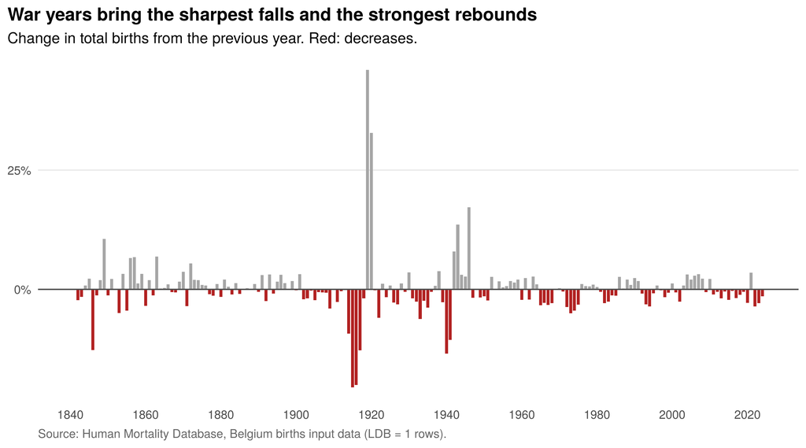

```r
ggplot(filter(tot, !is.na(pct_change)), aes(Year, pct_change, fill = pct_change > 0)) +
  geom_col(width = 0.8) +
  geom_hline(yintercept = 0, colour = "grey30") +
  scale_fill_manual(values = c(`TRUE` = grey, `FALSE` = "firebrick"), guide = "none") +
  scale_x_continuous(breaks = seq(1840, 2020, 20)) +
  scale_y_continuous(labels = function(x) paste0(x, "%")) +
  labs(
    title = "War years bring the sharpest falls and the strongest rebounds",
    subtitle = "Change in total births from the previous year. Red: decreases.",
    x = NULL, y = NULL, caption = hmd_caption
  )
```

**So what:** shocks like war mostly *delay* births rather than cancel them. When the shock ends, many of the postponed births happen quickly.

# Insight 3: The baby boom, then the bust

Births climbed after 1945 and peaked at **160,838 in 1964**. Then came the bust: a 29% fall in 21 years, to 114,092 in 1985. This drop lines up with the arrival of the contraceptive pill, more women in education and paid work, and later parenthood.

**So what:** unlike the wars, this fall did not bounce back. It was a lasting change in how many children people chose to have.

# Insight 4: Since 2008, a slow slide to a new low

After a small rise to **128,049 in 2008**, births fell in 14 of the 16 years that followed, down 15% to **109,154 in 2024**.

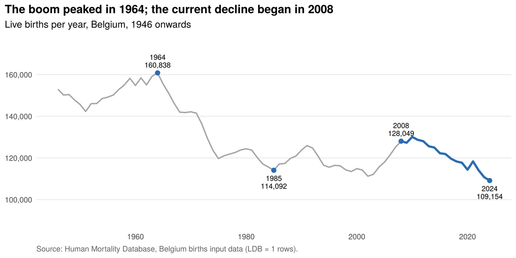

```r
recent <- filter(tot, Year >= 1946)
ggplot(recent, aes(Year, births)) +
  geom_line(colour = grey, linewidth = 0.8) +
  geom_line(data = filter(recent, Year >= 2008), colour = accent, linewidth = 1.3) +
  geom_point(data = filter(recent, Year %in% c(1964, 1985, 2008, last_year)),
             colour = accent, size = 2.4) +
  geom_text(data = filter(recent, Year %in% c(1964, 1985, 2008, last_year)),
            aes(label = paste0(Year, "\n", fmt(births))),
            vjust = c(-0.4, 1.4, -0.4, 1.4), size = 3.2, lineheight = 0.9) +
  scale_y_continuous(labels = label_comma(), limits = c(90000, 175000)) +
  labs(
    title = "The boom peaked in 1964; the current decline began in 2008",
    subtitle = "Live births per year, Belgium, 1946 onwards",
    x = NULL, y = NULL, caption = hmd_caption
  )
```

**So what:** this is the first long decline without a war or crisis to explain it, and there is no sign of a rebound yet.

# Insight 5: The boy–girl balance barely moves

Across the whole series, the average sex ratio at birth is **105.2 boys per 100 girls**, close to the normal biological ratio of about 105. That steadiness is a good sign the records are reliable.

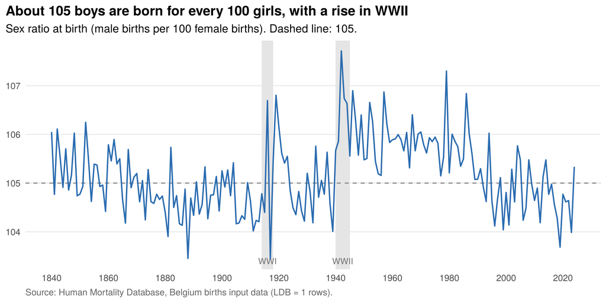

```r
ggplot(tot, aes(Year, sex_ratio)) +
  add_war_bands() +
  geom_hline(yintercept = 105, linetype = "dashed", colour = "grey50") +
  geom_line(colour = accent, linewidth = 0.7) +
  scale_x_continuous(breaks = seq(1840, 2020, 20)) +
  labs(
    title = "About 105 boys are born for every 100 girls, with a rise in WWII",
    subtitle = "Sex ratio at birth (male births per 100 female births). Dashed line: 105.",
    x = NULL, y = NULL, caption = hmd_caption
  )
```

The box plot shows the same data grouped by period. The WWII years sit clearly higher, a pattern other countries’ wartime data also show and sometimes called the “returning soldier effect”.

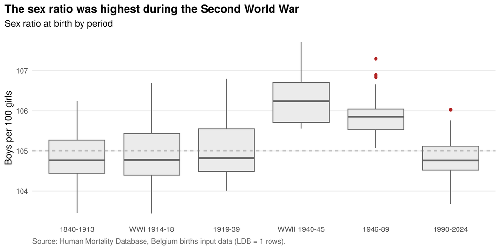

```r
ggplot(tot, aes(period, sex_ratio)) +
  geom_boxplot(fill = "grey92", colour = "grey40", outlier.colour = "firebrick") +
  geom_hline(yintercept = 105, linetype = "dashed", colour = "grey50") +
  labs(
    title = "The sex ratio was highest during the Second World War",
    subtitle = "Sex ratio at birth by period",
    x = NULL, y = "Boys per 100 girls", caption = hmd_caption
  )
```

```r
tot %>%
  group_by(Period = period) %>%
  summarise(
    Years = n(),
    `Mean sex ratio` = round(mean(sex_ratio), 2),
    `Mean births per year` = fmt(mean(births))
  )
```

| Period | Years | Mean sex ratio | Mean births per year |
| --- | --- | --- | --- |
| 1840-1913 | 74 | 104.89 | 163,821 |
| WWI 1914-18 | 5 | 104.95 | 110,354 |
| 1919-39 | 21 | 105.02 | 144,478 |
| WWII 1940-45 | 6 | 106.36 | 117,119 |
| 1946-89 | 44 | 105.88 | 138,481 |
| 1990-2024 | 35 | 104.79 | 119,425 |

**So what:** the total number of births changed a lot, but the mix of boys and girls did not. The story is about how many children are born, not which sex.

# Conclusion

Belgium’s birth record shows two kinds of decline. **Shocks** like famine and war cause deep but short drops, and births recover once the crisis ends. **Structural change**, like the post-1964 bust and the fall since 2008, brings slower declines that do not recover.

The current decline belongs to the second kind. In 2024, Belgium had fewer births than in any peacetime year on record, and the trend is still pointing down.

> **Takeaway:** Belgium’s births are falling with no war to blame, which suggests a lasting change in family choices rather than a temporary dip.

# Data notes and limits

```r
area130 <- raw %>%
  filter(Area == 130) %>%
  group_by(Year) %>%
  summarise(ratio = sum(Births[Sex == "m"]) / sum(Births[Sex == "f"]) * 100)

overlap_2010 <- raw %>%
  filter(Year == 2010) %>%
  group_by(Area, LDB) %>%
  summarise(births = sum(Births), .groups = "drop")
```

- **Counts, not rates.** Fewer births can mean smaller families or just fewer women of childbearing age. This data cannot tell the two apart on its own.
- **Series break in 2010.** Two sources overlap in 2010. The newer one (Area 30) reports 927 more births than the older one (Area 20).
- **Area 130 is excluded.** It is a small sub-series with a sex ratio between 118 and 164 boys per 100 girls, which no real population produces. It is flagged `LDB = 0`.
- **1830–1839 are excluded** because HMD does not use them (`LDB = 0`).

**Next steps:** divide births by population to get the crude birth rate, add the total fertility rate from the Human Fertility Database, and compare with neighbouring countries.

# Reproducibility

This report was written in R (R Core Team 2024) with ggplot2 (Wickham 2016). To rebuild it, run `source("render.R")` from the project root.

# References

Data obtained through the Human Mortality Database (www.mortality.org) in 2026. The input data remain under the original provider’s licence.

HMD. 2026. “Human Mortality Database.” Max Planck Institute for Demographic Research (Germany), University of California, Berkeley (USA), and French Institute for Demographic Studies (France). https://www.mortality.org.

R Core Team. 2024. *R: A Language and Environment for Statistical Computing*. Vienna, Austria: R Foundation for Statistical Computing. https://www.R-project.org/.

Wickham, Hadley. 2016. *Ggplot2: Elegant Graphics for Data Analysis*. Springer-Verlag New York. https://ggplot2.tidyverse.org.

Wilmoth, John R., Kirill Andreev, Dmitri Jdanov, Dana A. Glei, Tim Riffe, Carl Boe, Magali Bubenheim, et al. 2021. “Methods Protocol for the Human Mortality Database (V6).” Human Mortality Database. https://www.mortality.org.